# Итоговый проект

Группа 5

### Предобработка

Загрузка необходимых пакетов:

```r
library(tidyverse)
library(stringr)
library(SnowballC)
library(dplyr)
library(ggraph)
library(igraph)
library(tidyr)
library(LDAvis)
library(topicmodels)
library(tidytext)
library(recommenderlab)
```

#### Текстовый анализ

Перед построением рекомендательных систем мы решили провести текстовый анализ, а именно оценку тональности и LDA-анализ, чтобы выявить новые характеристики фильмов, которые можно было бы использовать впоследствии в content-based системе. Перед этим мы с сайта kaggle выгрузили дата-сет с дополнительными характеристиками, которые также решили использовать.

Выгрузка дополнительного дата-сета:

```r
df1 <- read.csv("~/shared/minor2_2022_5/movies_initial.csv")
```

Из этого дата-сета мы решили взять дополнительные харакетристики: год выхода фильма, жанр, описание фильмов. Описание фильмов мы решили использовать для текстового анализа, так как у большого количества фильмов не было тегов, а описание фильма почти у всех появилось.

```r
load("~/shared/minor2_2022/data/project/metadata_g_5.RData")
load("~/shared/minor2_2022/data/project/ratings_g_5.RData") #загрузили исходные дата-сеты
df1 = df1 %>% rename(imdbId = imdbID)
df1 = df1 %>% select(imdbId, year, genre, plot)
metadata$imdbId = as.integer(metadata$imdbId)
newdata = left_join(metadata, df1, by='imdbId') #соединяем дата-сеты
newdata = distinct(newdata) #убираем дублирующие строки
```

Попробуем выделить тональность на основе описания фильмов с помощью словаря afinn, предварительно проведя лемматизацию слов:

```r
afinn_sent = get_sentiments("afinn") #загрузка словаря с тональностью
plot = newdata %>%
  select(item_id, plot) %>%
  unnest_tokens(word, plot)

plot$word = str_to_lower(plot$word)
stopwords = data.frame(word=stopwords::stopwords("en"), stringsAsFactors=FALSE)
plot = plot %>%
  anti_join(stopwords)
```

```r
#лемматизация
plot$lem = wordStem(plot$word, language = "english") #из library(SnowballC)
```

```r
plot = plot %>% inner_join(afinn_sent)
plot_count = plot %>% group_by(item_id) %>% summarise(mean = mean(value))
newdata = left_join(newdata, plot_count)
newdata = distinct(newdata) #убираем дублирующие строки
s = sum(is.na(newdata$mean)) #получается 90/500 пропущенных
```

Получилось, что у 90 фильмов отсутсвует оценка тональности на основании описаня фильмов. Попробуем выделить тональность на основе тегов и “восполнить” пропуски.

```r
tag = inner_join(tags, survey_answers, by=c("id"="tag_id"))
#посмотрим на среднюю оценку тега
mean_score = tag %>% group_by(item_id, id) %>% summarise(mean = mean(score))
# будем считать, что теги со средней оценкой >1 подходят фильмам
mean_score = mean_score %>% filter(mean > 1)
film_tag = newdata %>% select(item_id) %>% inner_join(tag) %>% select(item_id, id, tag)
film_tag = film_tag %>%
  select(item_id, id, tag) %>%
  unnest_tokens(word, tag)

film_tag$lem = wordStem(film_tag$word, language = "english")

film_tag = film_tag %>% inner_join(afinn_sent, by=c("lem"="word"))
film.sent_count = film_tag %>%
  group_by(item_id) %>%
  summarise(mean = mean(value))
film.sent_count = film.sent_count %>% rename(mean1 = mean)

newdata = newdata %>% full_join(film.sent_count, by="item_id")
newdata$mean[is.na(newdata$mean)] = newdata$mean1[is.na(newdata$mean)] #заполняем пропуски значениями из столбца с тональностью по тегам
s = sum(is.na(newdata$mean)) #теперь только 68 пропущенныхданных
newdata = newdata %>% select(-mean1)
newdata = newdata %>% rename(sentiment = mean)
```

После заполнения пропусков с помощью тональности тегов, осталось 68 пропущенных данных. Заполним оставшиеся пропуски с помощью метода импутации, а именно: заполнение пропущенных строк средним значением.

```r
newdata$sentiment[is.na(newdata$sentiment)] = mean(newdata$sentiment, na.rm = TRUE)
```

Теперь оценку тональности можно использовать для построения Content-based системы.

Попробуем теперь выделить темы у фильмов на основании описаний с помощью LDA:

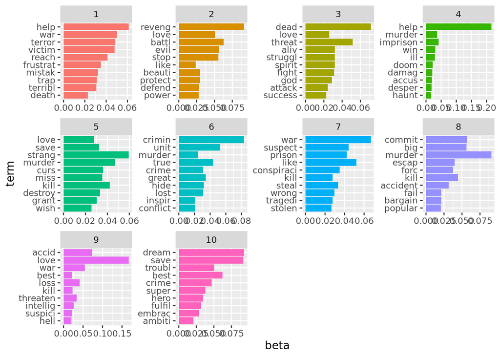

```r
word_counts = plot %>%
  count(item_id, lem, sort = TRUE) %>%
  ungroup()

plot_dtm <- word_counts %>% cast_dtm(item_id,lem, n)
plot_lda <- LDA(plot_dtm, k = 10, control = list(seed = 12345))

topics <- tidy(plot_lda, matrix = "beta")

terms <- topics %>%
  group_by(topic) %>%
  top_n(10, beta) %>%
  ungroup() %>%
  arrange(topic, -beta)

terms %>%
  mutate(term = reorder(term, beta)) %>%
  ggplot(aes(term, beta, fill = factor(topic))) +
  geom_col(show.legend = FALSE) +
  facet_wrap(~ topic, scales = "free") +
  coord_flip()
```

В ходе эксперементов в различными значениями параметра k (от 2 до 15), не получилось выделить темы фильмов, которые как-либо друг от друга отличались, поэтому данную характеристику мы не будем использовать для дальнейшего построения content-based системы.

#### Cетевой анализ

Начнём с того, что данный метод изначально предполагался как эксперементальный, но в итоге он был внедрён в рекомендательную систему. На первом шаге произведем обработку датасета: разбиение списка актеров по запятой и объединение в список

```r
#разбиение списка актеров по запятой и объединение в список
metadata$actor_list <- lapply(strsplit(metadata$starring, ","), function(x) as.character(x))
```

```r
#Создание объединенного датасета для дальнейшего создания фрейма: (фильм-актёр)
df = select(metadata, title, actor_list)
```

```r
#блок создания фрейма: (фильм-актёр)
edge = c()
for (i in 1:nrow(df)) {
  for (j in 1:length(df$actor_list[[i]])) {
  edge = c(edge, df$title[i], df$actor_list[[i]][j])
}
}
movies_actors = matrix(edge, ncol = 2, byrow = TRUE)
df_from_net = data.frame(film = movies_actors[,1], actor = movies_actors[,2])

#удалим лишние пробелы в колонках
df_from_net$film = trimws(df_from_net$film)
df_from_net$actor = trimws(df_from_net$actor)
```

На данном этапе представлена работа с python для предобработки данных

```r
network_dataset = read_csv("~/shared/minor2_2022_5/Seti/df_end.csv") #датасет, в котором связи между фильмами на основе актеров
```

Приступаем к построению сети:

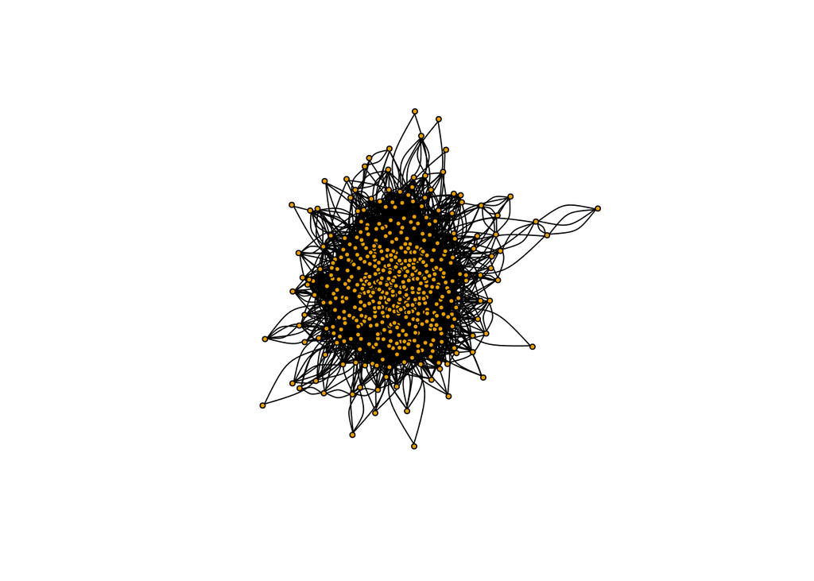

```r
g = graph_from_data_frame(d = network_dataset, directed = F)
plot(g,
     vertex.size = 3,
     vertex.label = NA,
     edge.color = "black")
```

Сам граф нам мало о чём говорит - его сложно интерпретировать. Посмотрим на характеристики сети.

```r
g
```

```
## IGRAPH 327d961 UN-- 477 7984 --
## + attr: name (v/c)
## + edges from 327d961 (vertex names):
## [1] 101 Dalmatians (1996)--Arachnophobia (1990)
## [2] 101 Dalmatians (1996)--Girl with the Dragon Tattoo, The (2011)
## [3] 101 Dalmatians (1996)--Harry Potter and the Half-Blood Prince (2009)
## [4] 101 Dalmatians (1996)--Air Force One (1997)
## [5] 101 Dalmatians (1996)--Harry Potter and the Chamber of Secrets (2002)
## [6] 101 Dalmatians (1996)--Squid and the Whale, The (2005)
## [7] 101 Dalmatians (1996)--Patriot, The (2000)
## [8] 101 Dalmatians (1996)--Event Horizon (1997)
## + ... omitted several edges
```

В сети 477 вершин (некоторые фильмы не вошли, так как у них не оказалось связей ни с одним фильмом) и почти 8 тысяч связей.

Почему Walktrap? “Подход, основанный на случайных путях. Основная идея – если случайно”блуждать” по графу, то больше шансов, что ваш путь будет чаще оставаться внутри сообщества и только иногда выходить за его пределы.”* (цитата из lab02-centrality) К тому же данный метод в представленной системе даёт более вариативное разбиение на комьюнити.

```r
#работа с сообществами
set.seed(1111)
wtcommune = walktrap.community(g)
com = wtcommune$membership
names = wtcommune$names
data = data_frame(com, names)
metadata$names = metadata$title
final_dataset = full_join(metadata, data, by = "names")

final_dataset[is.na(final_dataset)] = 0
final_dataset = final_dataset %>%
  select(-actor_list)

#write.csv(final_dataset, "df_from_project.csv")
```

Згачение модулярности у walktrap.community:

```r
modularity(wtcommune)
```

```
## [1] 0.2820818
```

Значение модулярности у fastgreedy.community:

```r
set.seed(123)
g = simplify(g)
fast = fastgreedy.community(g)
modularity(fast)
```

```
## [1] 0.2911561
```

```r
#membership(fast)

#ebc = edge.betweenness.community(g)
#Начинается бесконечная загрузка
```

Несмотря на то, что модулярность немного повыше у метода fastgreedy.community, но более вариативную разбивку мы получаем по методу walktrap.community, поэтому именно его мы будем использовать для выявления сообществ, также модулярность практически равна 0.3. Значение модулярности, лежащее в диапазоне от **0**.**3** до 0.7, означает, что сеть имеет вполне различимую структуру с сообществами, и применение алгоритма обнаружения сообществ имеет смысл.

По итогу сетевого анализа мы добавляем в набор данных такую характеристику как принадлежность к тому или иному комьюнити. Результатом стало выделение 34+1 комьюнити, которые по значению модулярности оказались обоснованно введёнными:

```r
newdata$community_id <- final_dataset$com
```

В дальнейшем для системы, основанной на контенте, комьюнити будет рассматриваться как фактор, то есть для каждого комьюнити будет создан отдельный столбец.

### Коллаборативная фильтрация

Присутпаем к построению коллаборативной фильтрации. Перед этим обработаем данные, чтобы было удобно использовать в построении модели:

```r
#Преобразуем к таблице в "широком" формате
rates = pivot_wider(ratings, names_from = item_id, values_from = rating)

#Оставляем только оценки
userNames = rates$user_id
rates = select(rates, -user_id)

#Преобразование таблицы данных в матрицу
rates = as.matrix(rates)
rownames(rates) = userNames
#Преобразование матрицы в realRatingMatrix
r = as(rates, "realRatingMatrix", strict = T)

#Убираем нерелевантные данные, более подробно, почему мы так сделали есть в ответах на вопросы peer review
ratings_movies <- r[rowCounts(r) > 15, colCounts(r) > 10]
```

Теперь можно построить модель коллаборативной фильтрации. Мы решили построить и IBCF, и UBCF, чтобы сравнить и выбрать наилучшую.

```r
#Разбиение данных на выборки с помощью 'evaluationScheme'
set.seed(100)
eval_sets <- evaluationScheme(data = ratings_movies,
                              method = "split",
                              train = 0.8, # доля обучающей выборки
                              given = 15, # сколько оценок используется для  предсказания
                              goodRating = 4) # если предсказанная оценка < 4, то фильм не рекомендуем
```

Модель IBCF: Строим модель на обучающей, предсказываем на тестовой:

```r
recc_model_IB <-
  Recommender(data = getData(eval_sets, "train"), method ="IBCF")

recc_predicted_IB <-
  predict(
    object = recc_model_IB,
    newdata = getData(eval_sets, "known"),
    n = 10,
    type = "ratings"
  )
```

Ищем усредненную accuracy для всех пользователей:

```r
eval_accuracy_IB <- calcPredictionAccuracy(
      x = recc_predicted_IB,# predicted values
      data = getData(eval_sets, "unknown"),
      byUser = F) # not averaging for each user

eval_accuracy_IB
```

```
##      RMSE       MSE       MAE
## 1.2783770 1.6342477 0.9478752
```

Модель UBCF: Строим модель на обучающей, предсказываем на тестовой:

```r
recc_model_UB <-
  Recommender(data = getData(eval_sets, "train"), method ="UBCF")

recc_predicted_UB <-
  predict(
    object = recc_model_UB,
    newdata = getData(eval_sets, "known"),
    n = 10,
    type = "ratings"
  )
```

Ищем усредненную accuracy для всех пользователей:

```r
eval_accuracy_UB <- calcPredictionAccuracy(
      x = recc_predicted_UB,# predicted values
      data = getData(eval_sets, "unknown"),
      byUser = F) # not averaging for each user

eval_accuracy_UB
```

```
##      RMSE       MSE       MAE
## 1.0879073 1.1835422 0.8461387
```

Мы выбрали для оценивания качесва модели RMSE. Видим, что ошибка меньше в случае user-based модели, поэтому далее для предсказаний будем использовать ее.

Пример использования: Возьмем пользователя с id=36989 и посмотрим, какие фильмы предсказала наша модель:

```r
recc_predicted = predict(object = recc_model_UB, newdata = ratings_movies, n = 10)

names(recc_predicted@items) = rownames(ratings_movies)
recc_user_1 = recc_predicted@items[["36989"]]
movies_user_1 = recc_predicted@itemLabels[recc_user_1]
names_movies_user_1 = metadata$title[match(movies_user_1, metadata$item_id)]
names_movies_user_1
```

```
##  [1] "Zootopia (2016)"                  "Bad Boys II (2003)"
##  [3] "Sleepy Hollow (1999)"             "Shaun of the Dead (2004)"
##  [5] "Goodfellas (1990)"                "Pulp Fiction (1994)"
##  [7] "What Lies Beneath (2000)"         "Love Actually (2003)"
##  [9] "Hunt for Red October, The (1990)" "Bucket List, The (2007)"
```

```r
names(recc_predicted@ratings) = rownames(ratings_movies)
```

Дополнительно рассматриваем случай, когда рекомендация нужна новому пользователю:

1. Получим список пользователей

```r
all_users = unique(ratings$user_id)
```

2. Получим топ 10 фильмов по общему рейтингу из metadata

```r
top_movies = head(metadata[order(-metadata$avgRating), "item_id"], 10)#топ фильмов, который будет выводиться для обеих моделей, если такого пользователя нет в отобранном списке
```

3. Получаем предсказание

```r
#user = '907977'
#user = '12345'
user = '356'
#user = '753874'
if (user %in% all_users == 0){
  movies_user = top_movies
} else {

    recc_predicted = predict(object = recc_model_UB, newdata = ratings_movies, n = 10)
    names(recc_predicted@items) = rownames(ratings_movies)
    recc_user = recc_predicted@items[[user]]
    movies_user = recc_predicted@itemLabels[recc_user]
  }
names_movies_user <- metadata$title[match(movies_user, metadata$item_id)]
names_movies_user
```

```
##  [1] "Hobbit: An Unexpected Journey, The (2012)"
##  [2] "History of Violence, A (2005)"
##  [3] "Meet the Parents (2000)"
##  [4] "Gattaca (1997)"
##  [5] "Blood Diamond (2006)"
##  [6] "The Count of Monte Cristo (2002)"
##  [7] "October Sky (1999)"
##  [8] "Pulp Fiction (1994)"
##  [9] "Saving Private Ryan (1998)"
## [10] "Eyes Wide Shut (1999)"
```

Функция:

```r
getUserBasedRecommendation=function(userId){

  if (as.character(userId) %in% rownames(ratings_movies) == 0){
    movies_user = top_movies
  } else {

    recc_predicted = predict(object = recc_model_UB, newdata = ratings_movies, n = 10) #в плане нами было указано, что пользователь получает 10 фильмов

    names(recc_predicted@items) = rownames(ratings_movies)
    recc_user_1 = recc_predicted@items[[as.character(userId)]]
    movies_user= recc_predicted@itemLabels[recc_user_1]
   }
  names_movies_user <- metadata$title[match(movies_user, metadata$item_id)]
  names_movies_user
}
```

Пример работы функции:

```r
userId=122658#предполагается ввод индекса в формате числа
getUserBasedRecommendation(userId)
```

```
##  [1] "Fighter, The (2010)"
##  [2] "Outbreak (1995)"
##  [3] "Goodfellas (1990)"
##  [4] "Ghost in the Shell (Kôkaku kidôtai) (1995)"
##  [5] "Alice in Wonderland (2010)"
##  [6] "Léon: The Professional (a.k.a. The Professional) (Léon) (1994)"
##  [7] "Ronin (1998)"
##  [8] "Stranger than Fiction (2006)"
##  [9] "Iron Giant, The (1999)"
## [10] "Patriot Games (1992)"
```

**Оценивание рекомендации:** Оценка на адекватность и внутренняя оценка

Для оценки качества модели методом коллаборативной фильтрации мы решили использовать RMSE и внутреннюю пользовательскую оценку. **RMSE** (Root Mean Squared Error) в рекомендательной системе фильмов для UBCF является метрикой оценки точност. предсказаний модели. Она измеряет разницу между фактическими рейтингами фильмов, которые пользователи дали, и предсказанными рейтингами модели. Оценка RMSE модели показала, что отклонение составляет около 1.08 балла по пятибалльной шкале, что хоть и не слишком мало, однако вполне допустимо в данном случае. Также получившееся значение меньше метрики RMSE у модели IBCF, откуда делаем вывод, что полученный показатель говорит о достаточно неплохой точности. Далее, после получения вопросов и комментариев от других студентов, мы с помощью цикла дополнительно проверили, грамотно ли подобраны границы отсечения, можно ли изменив их значительно уменьшить RMSE. По результатам такой проверки оказалось, что можно сократить RMSE до 0.98 балла, однако при этом пришлось бы оставить лишь пользователей и фильмы, у которых более 30 и 5 оценок соответственно, что слишком бы сократил выборку. Так что подобранное изначально отсечение является оптимальным вариантом, с точки зрения сохранения наблюдений и качества.

**Внутренняя оценка:**

Оценим рекомендации, которая дала система рандомно выбранному пользователю на предмет того, насколько схожи фильмы, исходя из собственных соображений, и насколько мы были бы удовлетворены таким подбором

```r
userId=633629#предполагается ввод индекса в формате числа
getUserBasedRecommendation(userId)
```

```
##  [1] "The Butterfly Effect (2004)"
##  [2] "Snowpiercer (2013)"
##  [3] "Expendables, The (2010)"
##  [4] "Slumdog Millionaire (2008)"
##  [5] "Help, The (2011)"
##  [6] "Stardust (2007)"
##  [7] "Birdman: Or (The Unexpected Virtue of Ignorance) (2014)"
##  [8] "25th Hour (2002)"
##  [9] "Princess Mononoke (Mononoke-hime) (1997)"
## [10] "Burn After Reading (2008)"
```

Это пользователь, который ставил оценки “5” фильмам в жанре приключения и ужасы. Как мы видим, подборка для такого набора вполне уместная, что говорит о качестве работы системы (о правильности построения логики модели).

### Content-based рекомендация

Для построения content-based мы решили использовать оценку тональности, разбиение на сообщества, жанр, среднюю оценку фильма, десятилетие выхода фильма.

Подготовим характеристики к построению модели:

```r
#Разбивка годов на десятилетия:
newdata$year = as.numeric(newdata$year)
newdata$decade = cut(newdata$year, breaks= c(1990, 2000, 2010, 2020, 2030), labels=c(1990, 2000, 2010, 2020))
newdata$decade_num = as.numeric(newdata$decade)

#Создание столбцов-жанров:
newdata$animation = as.numeric(str_detect(newdata$genre, "Animation"))
newdata$adventure = as.numeric(str_detect(newdata$genre, "Adventure"))
newdata$comedy = as.numeric(str_detect(newdata$genre, "Сomedy"))
newdata$drama = as.numeric(str_detect(newdata$genre, "Drama"))
newdata$romance = as.numeric(str_detect(newdata$genre, "Romance"))
newdata$action = as.numeric(str_detect(newdata$genre, "Action"))
newdata$sci_fi = as.numeric(str_detect(newdata$genre, "Sci"))
newdata$crime = as.numeric(str_detect(newdata$genre, "Crime"))
newdata$fantasy = as.numeric(str_detect(newdata$genre, "Fantasy"))
newdata$biography = as.numeric(str_detect(newdata$genre, "Biography"))
newdata$thriller = as.numeric(str_detect(newdata$genre, "Thriller"))
newdata$mystery = as.numeric(str_detect(newdata$genre, "Mystery"))
newdata$family = as.numeric(str_detect(newdata$genre, "Family"))
newdata$sport = as.numeric(str_detect(newdata$genre, "Sport"))
newdata$horror = as.numeric(str_detect(newdata$genre, "Horror"))
newdata$music = as.numeric(str_detect(newdata$genre, "Music"))
newdata$history = as.numeric(str_detect(newdata$genre, "History"))
newdata$documentary = as.numeric(str_detect(newdata$genre, "Documentary"))
newdata$western = as.numeric(str_detect(newdata$genre, "Western"))
newdata$musical = as.numeric(str_detect(newdata$genre, "Musical"))
newdata$short = as.numeric(str_detect(newdata$genre, "Short"))
newdata$war = as.numeric(str_detect(newdata$genre, "War"))

#Создание столбцов комьюнити:
newdata = newdata %>% pivot_wider( names_from = community_id, values_from = community_id, values_fn = length, values_fill = 0, names_prefix = "N_")
```

Преобразование дата-сета:

```r
data1 = newdata %>% dplyr::select(avgRating, item_id, decade_num, sentiment, N_0, N_1, N_2, N_3, N_4, N_5,N_6,N_7,N_8,N_9,N_10,N_11,N_12,N_13,N_14,N_15,N_16,N_17,N_18,N_19, N_20,N_21,N_22,N_23,N_24,N_25,N_26,N_27,N_28,N_29,N_30,N_31,N_32,N_33,N_34, animation, adventure, comedy, drama,romance,action,sci_fi,crime,fantasy,biography,thriller,mystery, family,sport,horror,music,history,documentary,western,musical,short,war)
rownames = data1$item_id
data1 = data1 %>% dplyr::select(-item_id)
rownames(data1) = rownames
```

Теперь можно приступить к построению рекомендательной системы:

```r
#Создаем матрицу схожести, используя косинусное расстояние.
sim1 = lsa::cosine(t(as.matrix(data1)))

#Проставим на главную диагональ 0, чтобы не получалось, что фильм больше всего похож сам на себя.
diag(sim1) = 0
```

Выводим рекомендацию для пользователя 38859:

```r
user = ratings %>% filter(user_id == 38859 & rating == 5)
#newdata %>% filter(item_id %in% user$item_id) %>% select(title, item_id)

mostSimilar = max(sim1[,as.character(user$item_id[1])], na.rm = T)
a = which(sim1[,as.character(user$item_id[1])] == mostSimilar, arr.ind = TRUE)

result = names(a)
#filter(newdata,item_id == result) %>% select(title)
```

Находим топ-10 фильмов с наибольшим показателем схожести.

```r
mostSimilar = head(sort(sim1[,as.character(user$item_id[2])], decreasing = T), n = 10)

#filter(newdata,item_id %in% result) %>% dplyr::select(title)

mostSimilar = data.frame(similar = mostSimilar)
mostSimilar$item_id = as.numeric(rownames(mostSimilar))
```

Оставим в матрице только нужные нам столбцы (т.е. соответствующие фильмам с высокой оценкой у рассматриваемого пользователя) в матрице схожести. Находим максимальное значение схожести по всем фильмам сразу и выводим рекомендацию.

```r
simCut = sim1[,as.character(user$item_id)]

mostSimilar = max(simCut, na.rm = T)
a = which(simCut == mostSimilar, arr.ind = TRUE)

#filter(newdata,item_id %in% result) %>% dplyr::select(title)
```

Сейчас выводим несколько рекомендаций сразу, упорядочиваем по убыванию схожести.

```r
mostSimilar = head(sort(simCut, decreasing = T), n = 10)
a = which(simCut %in% mostSimilar, arr.ind = TRUE, useNames = T)
index = arrayInd(a, .dim = dim(simCut))
result = rownames(sim1)[index[,1]]
result
```

```
##  [1] "59784"  "33162"  "4881"   "115569" "55118"  "33679"  "48516"  "2329"
##  [9] "7162"   "63876"
```

```r
filter(newdata,item_id %in% result) %>% dplyr::select(title, item_id)
```

```
## # A tibble: 10 × 2
##    title                            item_id
##    <chr>                              <int>
##  1 Man Who Wasn't There, The (2001)    4881
##  2 Nightcrawler (2014)               115569
##  3 Kung Fu Panda (2008)               59784
##  4 Kingdom of Heaven (2005)           33162
##  5 Cold Mountain (2003)                7162
##  6 Milk (2008)                        63876
##  7 American History X (1998)           2329
##  8 Eastern Promises (2007)            55118
##  9 Mr. & Mrs. Smith (2005)            33679
## 10 Departed, The (2006)               48516
```

```r
mostSimilar = data.frame(item_id = as.numeric(result),
                         similar = simCut[index])

mostSimilar %>% left_join(newdata) %>% select(item_id, title, similar) %>% arrange(-similar)
```

```
##    item_id                            title   similar
## 1    55118          Eastern Promises (2007) 0.9663613
## 2    48516             Departed, The (2006) 0.9642100
## 3     4881 Man Who Wasn't There, The (2001) 0.9620782
## 4    63876                      Milk (2008) 0.9610328
## 5    33679          Mr. & Mrs. Smith (2005) 0.9600074
## 6     7162             Cold Mountain (2003) 0.9596292
## 7   115569              Nightcrawler (2014) 0.9591882
## 8     2329        American History X (1998) 0.9574446
## 9    33162         Kingdom of Heaven (2005) 0.9557409
## 10   59784             Kung Fu Panda (2008) 0.9555597
```

```r
max_rating=ratings %>% select(-item_id) %>% group_by (user_id) %>% summarise(user_id=user_id, maximum=max(rating)) %>% unique()
#максимальная оценка, которую ставил пользователь: если самая высокая оценка ниже 4, то рекомендация выдается на основе наименее схожих фильмов с самым низко оцененным фильмом пользователя
min_rating=ratings %>% select(-item_id) %>% group_by (user_id) %>% summarise(user_id=user_id, minimum=min(rating)) %>% unique()
#минимальная оценка, которую ставил пользователь
```

Функция:

```r
getContentBasedRecommendation=function(userId){

  if (userId %in% ratings$user_id == 0){
    rec_s=metadata$title[match(top_movies, metadata$item_id)]
  } else {

    max_rating=max_rating %>% filter(user_id==userId)#находим максимальную оценку, поставленную искомым юзером - ищем фильмы по схожести с максимально оцененными этим пользователем

    if (max_rating$maximum>=4){
      user = ratings %>% filter(user_id == userId & rating == max_rating$maximum)
      simCut = sim1[,as.character(user$item_id)]

      mostSimilar = head(sort(simCut, decreasing = T), n = 10)

      a = which(simCut %in% mostSimilar, arr.ind = T, useNames = T)
      ## выдается результат "общим" индексом, а не строки-столбцы, нам нужны строки
      index = arrayInd(a, .dim = dim(sim1))

      # id фильмов
      result = rownames(sim1)[index[,1]]

      mostSimilar = data.frame(item_id = as.numeric(result),
                               similar = simCut[index])

      recs=mostSimilar %>% left_join(newdata) %>% select(item_id, title, similar) %>% arrange(-similar)
      for_delite = survey_answers %>%
        filter(user_id == userId)
      rec_s = anti_join(recs, for_delite)
    } else {

      min_rating=min_rating %>% filter(user_id==userId)#минимальная оценка пользователя для поиска наименее похожих фильмов

      user = ratings %>% filter(user_id == userId & rating == min_rating$minimum)
      simCut = sim1[,as.character(user$item_id)]

      lessSimilar = tail(sort(simCut, decreasing = T), n = 10)

      a = which(simCut %in% lessSimilar, arr.ind = T, useNames = T)
      # выдается результат "общим" индексом, а не строки-столбцы, нам нужны строки
      index = arrayInd(a, .dim = dim(sim1))

      # id фильмов
      result = rownames(sim1)[index[,1]]

      lessSimilar = data.frame(item_id = as.numeric(result),
                               similar = simCut[index])
      lessSimilar= lessSimilar %>% top_n(-lessSimilar$similar, n=10)

      recs=lessSimilar %>% left_join(newdata) %>% select(item_id, title, similar) %>% arrange(similar)
      for_delite = ratings %>%
        filter(user_id == userId)
      rec_s = anti_join(recs, for_delite)
      }}
 rec_s

}
```

Пример работы функции:

```r
userId=77170#предполагается ввод индекса в формате числа

getContentBasedRecommendation(userId)
```

```
##    item_id                                        title   similar
## 1    89492                             Moneyball (2011) 0.9593105
## 2    88163                  Crazy, Stupid, Love. (2011) 0.9592034
## 3    33162                     Kingdom of Heaven (2005) 0.9557409
## 4    59784                         Kung Fu Panda (2008) 0.9555597
## 5     6377                          Finding Nemo (2003) 0.9538688
## 6    91535                    Bourne Legacy, The (2012) 0.9416423
## 7     7458                                  Troy (2004) 0.9414574
## 8   116823 The Hunger Games: Mockingjay - Part 1 (2014) 0.9414544
## 9    56152                             Enchanted (2007) 0.9412767
## 10   47610                      Illusionist, The (2006) 0.9396495
```

**Оценивание рекомендации:** Для оценки качества content-based модели использовалась проверка на адекватность и внутренняя оценка.

**Внутренняя оценка**

Возьмём всё того же пользователя любителя приключений и ужасов, юзера под номером 633629.

Подставим его в функцию:

```r
userId=633629#предполагается ввод индекса в формате числа

getContentBasedRecommendation(userId)
```

```
##    item_id                                      title   similar
## 1    88140  Captain America: The First Avenger (2011) 0.9993313
## 2   110102 Captain America: The Winter Soldier (2014) 0.9992207
## 3     5349                          Spider-Man (2002) 0.9992035
## 4      471                Hudsucker Proxy, The (1994) 0.9919707
## 5      515             Remains of the Day, The (1993) 0.9878042
## 6     2396                 Shakespeare in Love (1998) 0.9855765
## 7     5349                          Spider-Man (2002) 0.9852359
## 8    63113                   Quantum of Solace (2008) 0.9836053
## 9   119145        Kingsman: The Secret Service (2015) 0.9836053
## 10   89745                       Avengers, The (2012) 0.9813970
## 11  119145        Kingsman: The Secret Service (2015) 0.9813970
```

**Проверка на адекватность** Сравнивались характеристики фильмов, которые нравятся пользователю, и тех, которые рекомендуются. Это включало в себя сравнение средней оценки фильмов и сравнение распредления доли жанров фильмов.

Возьмем пользователя 38859. Найдем характеристики фильмов, которые ему нравятся,и характеристики рекомендаций

```r
user = ratings %>% filter(user_id == 38859 & rating == 5)

liked <- filter(newdata,item_id %in% user$item_id)
recs <- filter(newdata,item_id %in% mostSimilar$item_id)
```

Проведем сравнение средней оценки фильмов, которые нравятся пользователю, с рекомендованными.

```r
mean_liked <- mean(liked$avgRating)
mean_recs <- mean(recs$avgRating)

cat("Средняя оценка фильмов, которые нравятся пользователю:", mean_liked, "\n")
```

```
## Средняя оценка фильмов, которые нравятся пользователю: 3.767487
```

```r
cat("Средняя оценка рекомендованных фильмов:", mean_recs, "\n")
```

```
## Средняя оценка рекомендованных фильмов: 3.739118
```

```r
dif_mean = mean_liked - mean_recs
cat("Разница средних: ", dif_mean)
```

```
## Разница средних:  0.02836867
```

Сравнение доли распределения жанров. Посчитаем, как часто тот или иной жанр встречается в любимых фильмах пользователя, и сравним с частотой распределения жанров рекомендаций.

```r
liked_genre_counts <- colSums(liked[, 16:37])
liked_genre_proportions <- liked_genre_counts / nrow(liked)
liked_genre_proportions <- liked_genre_proportions[order(liked_genre_proportions, decreasing = TRUE)]

recs_genre_counts <- colSums(recs[, 16:37])
recs_genre_proportions <- recs_genre_counts / nrow(recs)
recs_genre_proportions <- recs_genre_proportions[order(recs_genre_proportions, decreasing = TRUE)]
```

Преобразуем данные в датафреймы и выведем таблицу с разницей долей понравившихся и рекомендованных фильмов.

```r
liked_genre_df <- data.frame(genre = names(liked_genre_proportions), proportion = liked_genre_proportions, row.names = NULL)

recs_genre_df <- data.frame(genre = names(recs_genre_proportions), proportion = recs_genre_proportions, row.names = NULL)

genre_diff <- recs_genre_df %>% select(genre)
genre_diff$difference = liked_genre_df$proportion - recs_genre_df$proportion

genre_diff
```

```
##          genre  difference
## 1        drama  0.06666667
## 2        crime -0.26666667
## 3       action  0.03333333
## 4     thriller -0.13333333
## 5      history -0.03333333
## 6      romance  0.06666667
## 7    biography  0.06666667
## 8       sci_fi  0.16666667
## 9      fantasy  0.00000000
## 10     mystery  0.00000000
## 11      family  0.00000000
## 12       sport  0.00000000
## 13      horror  0.00000000
## 14       music  0.00000000
## 15 documentary  0.00000000
## 16     western  0.00000000
## 17     musical  0.00000000
## 18       short  0.00000000
## 19         war  0.00000000
## 20         N_9  0.00000000
## 21        N_14  0.00000000
## 22         N_3  0.00000000
```

### Примеры

В рамках peer review мы получили несколько предложений того, какие примеры нам стоит рассмотреть в нашей рекомендации. Мы разделим их на несколько групп, так как часть наших и предложенных примеров была похожа по логике. Рассмотрим примеры на collaborative filtering системе.

**1. Случай, когда пользователя в системе нет или у него мал оценок** Например, пользователя нет в системе (сделаем для нескольких новых пользователей, чтобы убедиться, что все получают одинаковый топ-10 фильмов)

```r
userId=0000 #предполагается ввод индекса в формате числа
getUserBasedRecommendation(userId)
```

```
##  [1] "Shawshank Redemption, The (1994)"
##  [2] "Spirited Away (Sen to Chihiro no kamikakushi) (2001)"
##  [3] "Lives of Others, The (Das leben der Anderen) (2006)"
##  [4] "Goodfellas (1990)"
##  [5] "Pulp Fiction (1994)"
##  [6] "Princess Mononoke (Mononoke-hime) (1997)"
##  [7] "Silence of the Lambs, The (1991)"
##  [8] "Memento (2000)"
##  [9] "American History X (1998)"
## [10] "Departed, The (2006)"
```

```r
userId=9999 #предполагается ввод индекса в формате числа
getUserBasedRecommendation(userId)
```

```
##  [1] "Shawshank Redemption, The (1994)"
##  [2] "Spirited Away (Sen to Chihiro no kamikakushi) (2001)"
##  [3] "Lives of Others, The (Das leben der Anderen) (2006)"
##  [4] "Goodfellas (1990)"
##  [5] "Pulp Fiction (1994)"
##  [6] "Princess Mononoke (Mononoke-hime) (1997)"
##  [7] "Silence of the Lambs, The (1991)"
##  [8] "Memento (2000)"
##  [9] "American History X (1998)"
## [10] "Departed, The (2006)"
```

```r
userId=192 #предполагается ввод индекса в формате числа
getUserBasedRecommendation(userId)
```

```
##  [1] "Shawshank Redemption, The (1994)"
##  [2] "Spirited Away (Sen to Chihiro no kamikakushi) (2001)"
##  [3] "Lives of Others, The (Das leben der Anderen) (2006)"
##  [4] "Goodfellas (1990)"
##  [5] "Pulp Fiction (1994)"
##  [6] "Princess Mononoke (Mononoke-hime) (1997)"
##  [7] "Silence of the Lambs, The (1991)"
##  [8] "Memento (2000)"
##  [9] "American History X (1998)"
## [10] "Departed, The (2006)"
```

**2. Рекомендации для пользователя, который предпочитает определенные жанры** Нам предложили посмотреть, что будет рекомендовано пользователю, которому нравятся фильмы “Lilo & Stitch (2002)”, “Cable Guy, The (1996)”, “Garden State (2004)”, “Dazed and Confused (1993)”. Также просили проверить, что будет, если ввести определенный жанр, например мультфильмы. Мы обобщим эти два запроса. У наших систем не предусмотрена возмжность давать рекомендации по жанру, однако мы решили проверить, насколько рекомендации соответствуют любимому жанру пользователя. Было достаточно cложно выбрать человека, который бы ставил высокие оценки только одному жанру и при этом оценил более 10 фильмов, поэтому возьмем user id 2543. Этот человек ставил высокие оценки мультфильмам (Южный парк, Суперсемейка и др) и драмам/романтическим фильмам (Форрест Гамп, Умница Уилл Хантинг). Выведем рекомендации для него:

```r
userId=2543 #предполагается ввод индекса в формате числа
getUserBasedRecommendation(userId)
```

```
##  [1] "Nightmare Before Christmas, The (1993)"
##  [2] "March of the Penguins (Marche de l'empereur, La) (2005)"
##  [3] "Spirited Away (Sen to Chihiro no kamikakushi) (2001)"
##  [4] "American Beauty (1999)"
##  [5] "Harry Potter and the Chamber of Secrets (2002)"
##  [6] "Bucket List, The (2007)"
##  [7] "Zootopia (2016)"
##  [8] "Monsters, Inc. (2001)"
##  [9] "Grand Canyon (1991)"
## [10] "Beauty and the Beast (1991)"
```

Видим, что большинство фильмов соответствуют его любимым жанрам, есть как рекомендации мультфильмов, например, Зверополис, Корпорация Монстров, Унесенные призраками, так и драмы (в том числе романтические), такие как Красота по-американски, Гранд-Каньон и даже один документальный фильм. В целом, рекомендация довольно хорошая, особенно с точки зрения разнообразия, но особенно стоит отметить рекомендации мультфильмов (все супер).

```r
userId=466317
getUserBasedRecommendation(userId)
```

```
##  [1] "Spirited Away (Sen to Chihiro no kamikakushi) (2001)"
##  [2] "Dances with Wolves (1990)"
##  [3] "October Sky (1999)"
##  [4] "Fargo (1996)"
##  [5] "Gladiator (1992)"
##  [6] "Brick (2005)"
##  [7] "Cloverfield (2008)"
##  [8] "Pulp Fiction (1994)"
##  [9] "Nightmare Before Christmas, The (1993)"
## [10] "25th Hour (2002)"
```

### Проверка предложенного сценария (по итогам оценки черновиков отчета по проекту)

Предложено посмотреть на рекомендацию фильмов пользователю, котрому нравятся фильмы с Джимом Керри и сравнить рекомендации методом CF и CB. **CF** Сначала попробуем на примере уже имеюшегося пользователя:

```r
userId=65192 #предполагается ввод индекса в формате числа
getUserBasedRecommendation(userId)
```

```
##  [1] "Erin Brockovich (2000)"
##  [2] "What Lies Beneath (2000)"
##  [3] "Expendables, The (2010)"
##  [4] "Lord of the Rings: The Two Towers, The (2002)"
##  [5] "Slumdog Millionaire (2008)"
##  [6] "25th Hour (2002)"
##  [7] "Magnolia (1999)"
##  [8] "Man from Earth, The (2007)"
##  [9] "Maverick (1994)"
## [10] "Memento (2000)"
```

Теперь добавим любителя фильмов с Джимом Керри (для этого придется вернуться к пстроению матрицы, так как пользователя нужно добавлять к исходному датафрейму)

```r
jim_carrey_fan = data.frame(item_id = c(27706, 3988, 471, 153, 19, 3752, 318, 5618, 44555, 800, 177765, 80463, 2, 87430, 8360, 52885),
                            user_id = c(9990000, 9990000, 9990000, 9990000, 9990000, 9990000, 9990000, 9990000, 9990000, 9990000, 9990000, 9990000, 9990000, 9990000, 9990000, 9990000),
                            rating = c(5.0, 5.0, 0.5, 5.0, 5.0, 5.0, 2.0, 2.0, 2.0, 2.0, 3.0, 2.5, 3.0, 1.5, 3.0, 2.0))
ratings = rbind(ratings, jim_carrey_fan)

rates = pivot_wider(ratings, names_from = item_id, values_from = rating)
userNames = rates$user_id
rates = select(rates, -user_id)
rates = as.matrix(rates)
rownames(rates) = userNames
r = as(rates, "realRatingMatrix", strict = T)
ratings_movies <- r[rowCounts(r) > 15, colCounts(r) > 10]

set.seed(100)
    eval_sets <- evaluationScheme(data = ratings_movies,
                                method = "split",
                                train = 0.8, # доля обучающей выборки
                                given = 15, # сколько оценок используется для  предсказания
                                goodRating = 4) # если предсказанная оценка < 4, то фильм не рекомендуем

recc_model_UB = Recommender(data = getData(eval_sets, "train"), method ="UBCF")
recc_predicted = predict(object = recc_model_UB, newdata = ratings_movies, n = 10)

getUserBasedRecommendation(9990000)
```

```
##  [1] "Léon: The Professional (a.k.a. The Professional) (Léon) (1994)"
##  [2] "Hunt for Red October, The (1990)"
##  [3] "Mrs. Doubtfire (1993)"
##  [4] "Lord of the Rings: The Two Towers, The (2002)"
##  [5] "Love Actually (2003)"
##  [6] "American Beauty (1999)"
##  [7] "xXx (2002)"
##  [8] "Memento (2000)"
##  [9] "Sling Blade (1996)"
## [10] "Match Point (2005)"
```

Видим опять же очень пртиворечивые рекомендации, среди них снова нет фильмов с Джимом Керри. Есть комедии, например Mrs. Doubtfire, триллеры и боевики, например Hunt for Red October, так и драмы, такие как Match Point. Опять же очень разнобразные рекмендации, которые объясняются скорее сутью User-Based рекомендательной системы, чем похожестью фильмов.

Теперь посмотрим на примере работы CB системы. Оценим пользователя, который уже был в системе:

```r
getContentBasedRecommendation(65192)
```

```
##    item_id                                                  title   similar
## 1     1673                                   Boogie Nights (1997) 0.9999971
## 2     2253                                            Toys (1992) 0.9917776
## 3     3160                                        Magnolia (1999) 0.9873092
## 4      300                                       Quiz Show (1994) 0.9741321
## 5      720 Wallace & Gromit: The Best of Aardman Animation (1996) 0.9677674
## 6     6377                                    Finding Nemo (2003) 0.9603606
## 7     3114                                     Toy Story 2 (1999) 0.9583907
## 8      552                           Three Musketeers, The (1993) 0.9578232
## 9     3897                                   Almost Famous (2000) 0.9565435
## 10    5349                                      Spider-Man (2002) 0.9555583
```

Для пользователя, который уже был в системе, не были подобраны фильмы с Керри, что может быть связано с тем, что пользователь посмотрелвсе фильмы с данным актёром (повторы фильтруются), либо с тем, что система просто проигнорировала этот факт.

### Выводы

В ходе работы мы провели сетевой и текстовый анализ данных о фильмах и пользователях, а также построили модели коллаборативной фильтрации (CF) и контентной базы (CB) для рекомендации фильмов и оценили их несколькими способами. В результате в нашем проекте мы получили две системы, которые позволяют пользователю получить рекомендации фильмов, введя свой id пользователя.

В рамках проведенного текстового анализа, мы добавили датасет с описаниями фильмов, а также смогли получить новую характеристику - оценку тональности, которая затем была использована в построении модели CB. Сетевой анализ, который был реализован с помощью Python и R, позволил нам построить сеть, где связями являются актеры, игравшие в нескольких фильмах, и выделить коммьюнити по фильмам, которые также использовались в построении модели.

Также мы построили модель CF, которая основывается на имеющихся оценках пользователя и рекомендует ему фильмы с высокой предсказанной оценкой. А также мы создали CB модель, которая учитывает не только среднюю оценку фильма, но и жанр, тональность коммьюнити, а также десятилетие выхода фильма. Последний показатель вызвал много вопросов, однако нам показалось, что он вполне логично вписывается в нашу рекомендательную модель, так как часто случаются ситуации, когда пользователи предпочитают смотреть только фильмы из определенной эпохи. Фильмы, выпущенные в одно десятилетие, часто имеют схожие стили, тематику и характеристики, а использование этого параметра в модели позволяет учесть данный аспект.

Далее мы превратили обе модели в функции и провели их оценку разными методами, в результате чего мы сделали выводы о точности и адекватности модели. И наконец, мы представили самые интересные и наглядные примеры их работы. Благодаря примерам из peer review и нашим собственным идеям, мы смогли продемонстрировать, как работают наши рекомендательные системы и оценить их работу еще более наглядно.

Таким образом, в рамках данного проекта мы смогли ближе познакомиться с построением рекомендательных систем, понять, как текстовый и сетевой анализ могут помочь нам в этом вопросе. В результате нашей работы мы провели комплексный анализ данных о фильмах и пользователях, построили модели CF и CB для рекомендации фильмов. Также, хочется отметить, что мы смогли отлично наладить работу в команде, четко распределять обязанности, вместе находить ошибки и неточности в работе и устранять их. Полученные нами модели могут быть полезны для создания персонализированных рекомендаций фильмов

### Ответы на вопросы peer review

**Вопрос: Почему использовали уже существующий словарь afinn, а не создали свой или любой другой?**

*Ответ:* Наша задача была оценить фильмы на тональность, словарь afinn хорошо для этого подходил, так как в нем “оценки” слов были в виде вещественных чисел, это очень удобно для оценки общей тональности фильма. Мы рассматривали другие словари из get_sentiments. Bing не подошел, так как там было просто разделение на positive/negativе, без градации, какое слово более негативное, а какое позитивное. Loughran не подошел по такой же причине. А словарь nrc просто показывал “чувства”, нам это не подходило. Создавать свой собственный словарь мы не стали, так как это не имело смысла. Словарь afinn удовлетворял полностью нашим требованиям.